# FINAL PROJECT

```r
bivariate_vars <- c("Diabetes_Status", "Physical_Activity", "Family_History_of_Diabetes",
                   "Hypertension", "Diet", "Smoking", "BMI", "Fasting_Blood_Glucose")
# Assuming 'diabetes_df' exists and is prepared from previous steps
if(exists("diabetes_df") && is.data.frame(diabetes_df)){
    for(v in bivariate_vars){
         if (v %in% names(diabetes_df)) {
             print(paste(v, "- Class:", class(diabetes_df[[v]])))
             if(is.factor(diabetes_df[[v]])){
                 print(paste("  Levels:", paste(levels(diabetes_df[[v]]), collapse=", "), "(N=", nlevels(diabetes_df[[v]]), ")"))
                 print("  Table:")
                 print(table(diabetes_df[[v]])) # Show counts per level
             } else if (is.numeric(diabetes_df[[v]])) {
                 print(paste("  Summary:", paste(round(summary(diabetes_df[[v]]), 2), collapse=" / ")))
             }
         } else {
             print(paste(v, "- COLUMN NOT FOUND in diabetes_df."))
         }
    }
} else {
    print("ERROR: 'diabetes_df' dataframe not found or is not a dataframe before Bivariate Analysis.")
    # Optional: Stop execution if diabetes_df is critical and missing
    # stop("Execution halted: diabetes_df is required for Bivariate Analysis.")
}
```

```
## [1] "Diabetes_Status - Class: character"
## [1] "Physical_Activity - Class: character"
## [1] "Family_History_of_Diabetes - Class: character"
## [1] "Hypertension - Class: character"
## [1] "Diet - Class: character"
## [1] "Smoking - Class: character"
## [1] "BMI - Class: numeric"
## [1] "  Summary: 8.67 / 23.79 / 29.3 / 29.17 / 34.67 / 50.79"
## [1] "Fasting_Blood_Glucose - Class: numeric"
## [1] "  Summary: 57.63 / 91.33 / 134.39 / 127.88 / 160.82 / 199.96"
```

```r
print("--- End of Variable Verification ---")
```

```
## [1] "--- End of Variable Verification ---"
```

```r
# --- Execute Bivariate Tests ---
# Ensure results_list is re-initialized if running this section multiple times
results_list <- list()

# Run Chi-Squared tests (only if diabetes_df exists)
if(exists("diabetes_df") && is.data.frame(diabetes_df)){
    results_list <- c(results_list, list(run_chisq("Diabetes_Status", "Physical_Activity", "Diabetes_Status vs. Physical_Activity")))
    results_list <- c(results_list, list(run_chisq("Diabetes_Status", "Family_History_of_Diabetes", "Diabetes_Status vs. Family_History_of_Diabetes")))
    results_list <- c(results_list, list(run_chisq("Diabetes_Status", "Hypertension", "Diabetes_Status vs. Hypertension")))
    results_list <- c(results_list, list(run_chisq("Diabetes_Status", "Diet", "Diabetes_Status vs. Diet")))
    results_list <- c(results_list, list(run_chisq("Diabetes_Status", "Smoking", "Diabetes_Status vs. Smoking")))

    # Run tests for continuous variables vs Diabetes_Status
    results_list <- c(results_list, list(run_cont_vs_cat("BMI", "Diabetes_Status", "BMI by Diabetes_Status")))
    results_list <- c(results_list, list(run_cont_vs_cat("Fasting_Blood_Glucose", "Diabetes_Status", "Fasting_Blood_Glucose by Diabetes_Status")))
} else {
    print("Skipping Bivariate Test execution because 'diabetes_df' is not available.")
}
```

```
## [1] "--- Chi-Squared:  Diabetes_Status vs. Physical_Activity  ---"
## [1] "Checking vars: Diabetes_Status (Exists: TRUE ) vs Physical_Activity (Exists: TRUE )"
## [1] "Diabetes_Status Class: character ; Physical_Activity Class: character"
## [1] "Error: One or both variables are not factors."
## [1] "Attempting temporary factor conversion for Diabetes_Status"
## [1] "Attempting temporary factor conversion for Physical_Activity"
## [1] "Diabetes_Status Levels: 2 ; Physical_Activity Levels: 2"
## [1] "Levels for Diabetes_Status : Negative, Positive"
## [1] "Levels for Physical_Activity : No, Yes"
## [1] "Observed Table:"
##
##             No Yes
##   Negative 641 695
##   Positive 868 796
## [1] "Expected Counts:"
##
##             No Yes
##   Negative 672 664
##   Positive 837 827
## [1] "Minimum expected count: 663.99"
## [1] "Percentage of cells with expected count < 5: 0 %"
## [1] "Pearson Residuals (indicator for post-hoc):"
##
##               No   Yes
##   Negative -1.20  1.20
##   Positive  1.07 -1.08
## [1] "--- Chi-Squared:  Diabetes_Status vs. Family_History_of_Diabetes  ---"
## [1] "Checking vars: Diabetes_Status (Exists: TRUE ) vs Family_History_of_Diabetes (Exists: TRUE )"
## [1] "Diabetes_Status Class: character ; Family_History_of_Diabetes Class: character"
## [1] "Error: One or both variables are not factors."
## [1] "Attempting temporary factor conversion for Diabetes_Status"
## [1] "Attempting temporary factor conversion for Family_History_of_Diabetes"
## [1] "Diabetes_Status Levels: 2 ; Family_History_of_Diabetes Levels: 2"
## [1] "Levels for Diabetes_Status : Negative, Positive"
## [1] "Levels for Family_History_of_Diabetes : No, Yes"
## [1] "Observed Table:"
##
##              No  Yes
##   Negative 1197  139
##   Positive  309 1355
```

[output cut: 69 more lines]

```
##
##             No Yes
##   Negative 695 641
##   Positive 825 839
## [1] "Expected Counts:"
##
##               No   Yes
##   Negative 676.9 659.1
##   Positive 843.1 820.9
## [1] "Minimum expected count: 659.09"
## [1] "Percentage of cells with expected count < 5: 0 %"
## [1] "--- Comparison:  BMI by Diabetes_Status  ---"
## [1] "Error: Diabetes_Status is not a factor. Class: character"
## [1] "--- Comparison:  Fasting_Blood_Glucose by Diabetes_Status  ---"
## [1] "Error: Diabetes_Status is not a factor. Class: character"
```

```r
# --- Combine Bivariate Results into Table 2 ---
if (length(results_list) > 0) {
    results_list_clean <- results_list[!sapply(results_list, is.null)]
    if(length(results_list_clean) > 0) {
        # Handle cases where some elements might not have all columns if errors occurred
        # Ensure all elements are lists with the same names before rbind
        expected_names <- c("Test", "Variable_Pair", "Statistic", "p_value")
        results_list_formatted <- lapply(results_list_clean, function(item) {
            # Ensure item is a list
            if (!is.list(item)) item <- as.list(item)
            # Check names and add NA if missing (more robust)
            for (n in expected_names) {
                if (!n %in% names(item)) {
                    item[[n]] <- NA # Assign NA if a column is missing
                }
            }
            # Ensure correct order - this might not be strictly necessary if names match
             item <- item[match(expected_names, names(item))]
             # Convert to data frame row for consistency
             as.data.frame(item, stringsAsFactors = FALSE)
        })

        # Now rbind should work more reliably
        table2_data <- do.call(rbind, results_list_formatted)

        # Rename columns for final table display
        names(table2_data) <- c("Test", "Variable Pair", "Statistic", "p-value")

        print("--- Bivariate Analysis Table 2 ---")
        print(table2_data)
    } else {
        print("Could not generate Table 2 data - all bivariate tests failed or returned NULL.")
    }
} else {
    print("Could not generate Table 2 data - results list is empty.")
}
```

```
## [1] "--- Bivariate Analysis Table 2 ---"
##          Test                                  Variable Pair         Statistic
## 1 Chi-Squared          Diabetes_Status vs. Physical_Activity         χ²(1) = 5
## 2 Chi-Squared Diabetes_Status vs. Family_History_of_Diabetes    χ²(1) = 1492.5
## 3 Chi-Squared               Diabetes_Status vs. Hypertension       χ²(1) = 0.7
## 4 Chi-Squared                       Diabetes_Status vs. Diet       χ²(1) = 9.1
## 5 Chi-Squared                    Diabetes_Status vs. Smoking       χ²(1) = 1.7
## 6       Error                         BMI by Diabetes_Status Error: Not Factor
## 7       Error       Fasting_Blood_Glucose by Diabetes_Status Error: Not Factor
##   p-value
## 1   0.025
## 2  <0.001
## 3   0.389
## 4 0.00259
## 5   0.196
## 6   Error
## 7   Error
```

```r
# --- End of Section 5 ---
```

The Chi-squared tests revealed several significant associations between diabetes status and categorical predictors. A strong and statistically significant relationship was found between having a family history of diabetes and being diagnosed with diabetes, indicating a potential hereditary component. Similarly, physical activity and dietary habits showed significant associations with diabetes status, suggesting that lifestyle factors play a key role. In contrast, no significant associations were found between diabetes status and either smoking or hypertension, implying that these factors may not be independently linked to diabetes within this sample. These results highlight the relevance of modifiable behaviors and family background in the context of diabetes risk.

# Multivariate Analysis (Logistic Regression)

```r
# --- 6. Multivariate Analysis (Logistic Regression - CORRECT for Binary Outcome) ---

print("--- Running Multivariate Analysis (Logistic Regression) ---")
```

```
## [1] "--- Running Multivariate Analysis (Logistic Regression) ---"
```

```r
# Ensure 'car' package is installed for VIF check: install.packages("car")
library(car)

# Define predictors and dependent variable
predictors <- c("BMI", "Fasting_Blood_Glucose", "Physical_Activity", "Family_History_of_Diabetes", "Hypertension", "Diet", "Smoking")
dependent_var <- "Diabetes_Status"
required_glm_vars <- c(dependent_var, predictors)

# --- Rigorous Final Pre-GLM Check (Similar to RF) ---
print("--- Starting FINAL PRE-GLM Check & Fix ---")
```

```
## [1] "--- Starting FINAL PRE-GLM Check & Fix ---"
```

```r
# Assuming 'diabetes_df' exists and is prepared from previous steps
if(!exists("diabetes_df") || !is.data.frame(diabetes_df)){
    stop("FATAL ERROR [PRE-GLM]: 'diabetes_df' dataframe not found or is not a dataframe.")
}

# 1. Check Existence in diabetes_df
print("Checking variable existence in diabetes_df...")
```

```
## [1] "Checking variable existence in diabetes_df..."
```

```r
missing_glm_vars <- setdiff(required_glm_vars, names(diabetes_df))
if(length(missing_glm_vars) > 0){
    stop(paste("FATAL ERROR [PRE-GLM]: Required variables MISSING from diabetes_df:", paste(missing_glm_vars, collapse=", ")))
} else {
    print("All required GLM variables found in diabetes_df.")
}
```

```
## [1] "All required GLM variables found in diabetes_df."
```

```r
# 2. Check Dependent Variable Type and Levels in diabetes_df
print(paste("Checking", dependent_var, "in diabetes_df..."))
```

```
## [1] "Checking Diabetes_Status in diabetes_df..."
```

```r
if (!is.factor(diabetes_df[[dependent_var]])) {
    print(paste("WARNING [PRE-GLM]:", dependent_var, "is NOT a factor. Attempting conversion NOW."))
    # FORCE CONVERSION
    diabetes_df[[dependent_var]] <- factor(diabetes_df[[dependent_var]])
    if (!is.factor(diabetes_df[[dependent_var]])) {
        stop(paste("FATAL ERROR [PRE-GLM]: FAILED to convert", dependent_var, "to factor."))
    } else { print(paste("Conversion successful. New class:", class(diabetes_df[[dependent_var]]))) }
} else { print(paste(dependent_var, "is already a factor.")) }
```

```
## [1] "WARNING [PRE-GLM]: Diabetes_Status is NOT a factor. Attempting conversion NOW."
## [1] "Conversion successful. New class: factor"
```

```r
# 3. Check Dependent Variable Levels (MUST be 2 for binomial GLM)
current_levels <- levels(diabetes_df[[dependent_var]])
num_levels <- length(current_levels)
print(paste("Levels for", dependent_var, ":", paste(current_levels, collapse=", "), "(N=", num_levels, ")"))
```

```
## [1] "Levels for Diabetes_Status : Negative, Positive (N= 2 )"
```

```r
if (num_levels != 2) {
    stop(paste("FATAL ERROR [PRE-GLM]:", dependent_var, "does not have exactly 2 levels for Logistic Regression. Found:", num_levels))
} else { print(paste(dependent_var, "has exactly 2 levels. Check passed.")) }
```

```
## [1] "Diabetes_Status has exactly 2 levels. Check passed."
```

```r
# 4. Set/Confirm Reference Level (Important for Odds Ratio Interpretation)
# By default, R uses the first level alphabetically/numerically as reference (baseline)
# Ensure 'Negative' (or your baseline) is the reference level if you want OR > 1 to mean increased odds of 'Positive'
reference_level <- levels(diabetes_df[[dependent_var]])[1] # Get the current first level
positive_level <- levels(diabetes_df[[dependent_var]])[2] # Get the second level (outcome)
print(paste("Reference level for", dependent_var, "is:", reference_level))
```

```
## [1] "Reference level for Diabetes_Status is: Negative"
```

```r
print(paste("Odds ratios will represent the odds of '", positive_level, "' vs '", reference_level, "'", sep=""))
```

```
## [1] "Odds ratios will represent the odds of 'Positive' vs 'Negative'"
```

```r
# Example: Uncomment and modify if you NEED to change the reference level
# desired_reference <- "Negative" # Or your specific baseline category name
# if(reference_level != desired_reference && desired_reference %in% current_levels){
#    print(paste("Releveling", dependent_var, "to make '", desired_reference, "' the reference..."))
#    diabetes_df[[dependent_var]] <- relevel(diabetes_df[[dependent_var]], ref = desired_reference)
#    reference_level <- levels(diabetes_df[[dependent_var]])[1] # Update reference level
#    positive_level <- levels(diabetes_df[[dependent_var]])[2] # Update positive level
#    print(paste("New reference level:", reference_level))
#    print(paste("Odds ratios will now represent the odds of '", positive_level, "' vs '", reference_level, "'", sep=""))
# }

# 5. Check Predictor Types (Factors are okay, glm handles dummy coding)
print("Checking predictor variable types...")
```

```
## [1] "Checking predictor variable types..."
```

```r
for(pred in predictors){
    if(pred %in% names(diabetes_df)){ # Check if predictor exists
        print(paste(" ", pred, "- Class:", class(diabetes_df[[pred]])))
        if(!is.numeric(diabetes_df[[pred]]) && !is.factor(diabetes_df[[pred]])){
             print(paste("  WARNING:", pred, "is neither numeric nor factor. GLM might handle unexpectedly or fail."))
             # Optional: Attempt conversion if character
             if(is.character(diabetes_df[[pred]])){
                 print(paste("  Attempting factor conversion for", pred))
                 diabetes_df[[pred]] <- factor(diabetes_df[[pred]])
                 print(paste("  New Class:", class(diabetes_df[[pred]])))
             }
        } else if (is.factor(diabetes_df[[pred]])) {
             print(paste("   Levels:", paste(levels(diabetes_df[[pred]]), collapse=", ")))
        }
    } else {
         print(paste(" ", pred, "- WARNING: Predictor not found in diabetes_df (should have been caught earlier)."))
    }
}
```

```
## [1] "  BMI - Class: numeric"
## [1] "  Fasting_Blood_Glucose - Class: numeric"
## [1] "  Physical_Activity - Class: character"
## [1] "  WARNING: Physical_Activity is neither numeric nor factor. GLM might handle unexpectedly or fail."
## [1] "  Attempting factor conversion for Physical_Activity"
## [1] "  New Class: factor"
## [1] "  Family_History_of_Diabetes - Class: character"
## [1] "  WARNING: Family_History_of_Diabetes is neither numeric nor factor. GLM might handle unexpectedly or fail."
## [1] "  Attempting factor conversion for Family_History_of_Diabetes"
## [1] "  New Class: factor"
## [1] "  Hypertension - Class: character"
## [1] "  WARNING: Hypertension is neither numeric nor factor. GLM might handle unexpectedly or fail."
## [1] "  Attempting factor conversion for Hypertension"
## [1] "  New Class: factor"
## [1] "  Diet - Class: character"
## [1] "  WARNING: Diet is neither numeric nor factor. GLM might handle unexpectedly or fail."
## [1] "  Attempting factor conversion for Diet"
## [1] "  New Class: factor"
## [1] "  Smoking - Class: character"
## [1] "  WARNING: Smoking is neither numeric nor factor. GLM might handle unexpectedly or fail."
## [1] "  Attempting factor conversion for Smoking"
## [1] "  New Class: factor"
```

```r
print("--- Finished FINAL PRE-GLM Check & Fix ---")
```

```
## [1] "--- Finished FINAL PRE-GLM Check & Fix ---"
```

```r
# 6.1 Assumption Check: Multicollinearity
print("Checking for Multicollinearity...")
```

```
## [1] "Checking for Multicollinearity..."
```

```r
# Correlation for continuous predictors
continuous_predictors <- intersect(predictors, names(diabetes_df)[sapply(diabetes_df, is.numeric)])
if(length(continuous_predictors) >= 2){
    print(" Correlation between Continuous Predictors:")
    correlation_matrix <- cor(diabetes_df[, continuous_predictors, drop=FALSE], use = "pairwise.complete.obs")
    print(round(correlation_matrix, 2))
    # Check absolute correlation values excluding the diagonal
    cor_values_off_diag <- abs(correlation_matrix[lower.tri(correlation_matrix)])
    if(any(cor_values_off_diag > 0.8, na.rm=TRUE)) { print(" WARNING: High correlation (>0.8) detected between continuous predictors.") }
    else { print(" Correlation between continuous predictors is acceptable (<0.8).") }
} else { print(" Less than 2 continuous predictors, skipping correlation matrix.") }
```

```
## [1] " Correlation between Continuous Predictors:"
##                        BMI Fasting_Blood_Glucose
## BMI                   1.00                  0.42
## Fasting_Blood_Glucose 0.42                  1.00
## [1] " Correlation between continuous predictors is acceptable (<0.8)."
```

```r
# Note: VIF check is done *after* fitting the model below.


# 6.2 Prepare data subset FOR THE MODEL
print("Preparing data subset for Logistic Regression model...")
```

```
## [1] "Preparing data subset for Logistic Regression model..."
```

```r
model_data <- diabetes_df[, required_glm_vars, drop = FALSE] # Select only needed columns
model_data_complete <- na.omit(model_data) # Listwise deletion for missing data in model variables
print(paste("Initial rows in diabetes_df:", nrow(diabetes_df)))
```

```
## [1] "Initial rows in diabetes_df: 3000"
```

```r
print(paste("Rows available for GLM after na.omit on model variables:", nrow(model_data_complete)))
```

```
## [1] "Rows available for GLM after na.omit on model variables: 3000"
```

```r
# Check if enough data remains and if outcome still has 2 levels
# Rule of thumb: Need >10-20 events (cases in the less frequent outcome category) per predictor variable
min_outcome_freq <- min(table(model_data_complete[[dependent_var]]))
num_predictors <- length(predictors)
print(paste("Minimum frequency in outcome variable ('", names(which.min(table(model_data_complete[[dependent_var]]))), "'): ", min_outcome_freq, sep=""))
```

```
## [1] "Minimum frequency in outcome variable ('Negative'): 1336"
```

```r
print(paste("Number of predictors:", num_predictors))
```

```
## [1] "Number of predictors: 7"
```

```r
if (min_outcome_freq < (num_predictors * 10)) {
    print(paste("WARNING: Low number of events per predictor variable (<10). Model results might be unstable."))
}

if(nrow(model_data_complete) > (num_predictors + 1)) { # Check if rows > parameters
   final_levels_obj <- droplevels(model_data_complete[[dependent_var]])
   if (nlevels(final_levels_obj) == 2) {
       print("Running Logistic Regression model (glm)...")
       # Create formula
       model_formula_glm <- as.formula(paste(dependent_var, "~", paste(predictors, collapse = " + ")))
       print("Using formula:")
       print(model_formula_glm)

       # Fit the model
       logistic_model <- tryCatch({
           glm(model_formula_glm, data = model_data_complete, family = binomial(link = "logit"))
       }, error = function(e){
           print(paste("ERROR running glm:", e$message))
           # Common errors: complete separation (perfect prediction), singular matrix (perfect collinearity)
           return(NULL)
       })

       # Process results if model fitting succeeded
       if(!is.null(logistic_model)){
           print("--- Logistic Regression Model Summary ---")
           print(summary(logistic_model))

           # Check VIF (after model is successfully fit)
           print(" Checking Variance Inflation Factors (VIF)...")
           # Ensure all predictors included in VIF check are appropriate (not outcome)
           predictors_in_model_coef <- names(coef(logistic_model))[-1] # Get predictor names from model coefs, remove intercept
           # Clean predictor names if they involve factor levels (e.g., remove 'Yes' suffix)
           # This part can be complex depending on how factors are named
           # Simple approach: assume base names match original predictors list for check
           valid_predictors_for_vif <- predictors[predictors %in% attr(terms(logistic_model), "term.labels")]

           if(length(valid_predictors_for_vif) > 1){ # VIF requires at least 2 predictors
               vif_values <- tryCatch(vif(logistic_model), # Calculate VIF
                                     error=function(e){ print(paste(" Could not calculate VIF:", e$message)); NULL})
                if(!is.null(vif_values)){
                     print("VIF Values:")
                     print(round(vif_values, 2))
                     # Check VIF thresholds
                     if(any(vif_values > 10, na.rm = TRUE)){ print(" WARNING: VIF > 10 suggests potentially problematic multicollinearity.")}
                     else if(any(vif_values > 5, na.rm = TRUE)){ print(" WARNING: VIF > 5 suggests moderate multicollinearity may be present.")}
                     else {print(" VIF values appear acceptable (<5).")}
                }
           } else { print(" Skipping VIF check (less than 2 predictors remained in the final model or error).")}

           # 6.3 Calculate Odds Ratios and Confidence Intervals
           print("--- Odds Ratios (OR) and 95% Confidence Intervals (CI) ---")
           tryCatch({
               # Exponentiate coefficients and CIs
               or_coef <- exp(coef(logistic_model))
               # Use confint.default for potentially faster calculation on large models if profile likelihood is slow/fails
               # or_confint <- exp(confint.default(logistic_model))
               or_confint <- exp(confint(logistic_model)) # Uses profile likelihood by default

               # Get p-values from summary
               p_values <- summary(logistic_model)$coefficients[, "Pr(>|z|)"]

               # Combine into a table, ensuring row alignment
               coef_names <- names(or_coef)
               or_table_data <- list(
                   Predictor = coef_names,
                   OddsRatio = round(or_coef, 3),
                   CI_Lower = round(or_confint[coef_names, 1], 3), # Match by name
                   CI_Upper = round(or_confint[coef_names, 2], 3), # Match by name
                   pValue = round(p_values[coef_names], 4)         # Match by name
               )
               or_table <- as.data.frame(or_table_data)

               # Format p-values nicely
               or_table$pValueFormatted <- ifelse(or_table$pValue < 0.001, "<0.001", format(round(or_table$pValue, 3), nsmall=3))

               # Display Table 3 (Logistic Regression Results)
               print("--- Multivariate Analysis Table 3 (Logistic Regression ORs) ---")
               # Optional: Exclude intercept for typical predictor table?
               # print(or_table[or_table$Predictor != "(Intercept)", c("Predictor", "OddsRatio", "CI_Lower", "CI_Upper", "pValueFormatted")])
               print(or_table[, c("Predictor", "OddsRatio", "CI_Lower", "CI_Upper", "pValueFormatted")]) # Include intercept

               table3_data <- or_table # Assign for consistency

           }, error=function(e){
                print(paste("ERROR calculating/displaying Odds Ratios:", e$message))
                # Try to get coefficient names even if CIs failed
                coef_names_fallback <- tryCatch(names(coef(logistic_model)), error = function(e) predictors)
                table3_data <- data.frame(Predictor=coef_names_fallback, OddsRatio=NA, CI_Lower=NA, CI_Upper=NA, pValueFormatted=NA)
                print("--- Multivariate Analysis Table 3 (OR Error) ---")
                print(table3_data)
           })

       } else { # glm model fitting returned NULL (error)
            table3_data <- data.frame(Predictor=required_glm_vars[-1], OddsRatio=NA, CI_Lower=NA, CI_Upper=NA, pValueFormatted=NA) # Show predictors expected
            print("--- Multivariate Analysis Table 3 (Model Failed) ---")
            print(table3_data)
       }
   } else { # Not 2 levels after na.omit
       stop(paste("FATAL ERROR [POST-NA.OMIT]:", dependent_var, "in model_data_complete does not have exactly 2 levels after na.omit. Cannot run Logistic Regression."))
   }
} else { # Not enough data after na.omit
    print("Cannot run Logistic Regression model - insufficient complete cases after removing NAs for selected variables.")
    table3_data <- data.frame(Predictor=predictors, OddsRatio=NA, CI_Lower=NA, CI_Upper=NA, pValueFormatted=NA)
    print("--- Multivariate Analysis Table 3 (Insufficient Data) ---")
    print(table3_data)
}
```

```
## [1] "Running Logistic Regression model (glm)..."
## [1] "Using formula:"
## Diabetes_Status ~ BMI + Fasting_Blood_Glucose + Physical_Activity +
##     Family_History_of_Diabetes + Hypertension + Diet + Smoking
## [1] "--- Logistic Regression Model Summary ---"
##
## Call:
## glm(formula = model_formula_glm, family = binomial(link = "logit"),
##     data = model_data_complete)
##
## Coefficients:
##                                Estimate Std. Error z value Pr(>|z|)
## (Intercept)                   -6.153417   0.324564 -18.959  < 2e-16 ***
## BMI                            0.044807   0.009002   4.978 6.44e-07 ***
## Fasting_Blood_Glucose          0.031677   0.001747  18.130  < 2e-16 ***
## Physical_ActivityYes          -0.092146   0.116944  -0.788  0.43073
## Family_History_of_DiabetesYes  2.588260   0.127271  20.337  < 2e-16 ***
## HypertensionYes                0.256105   0.117466   2.180  0.02924 *
## DietYes                       -0.466564   0.118158  -3.949 7.86e-05 ***
## SmokingYes                     0.378068   0.118181   3.199  0.00138 **
## ---
## Signif. codes:  0 '***' 0.001 '**' 0.01 '*' 0.05 '.' 0.1 ' ' 1
##
## (Dispersion parameter for binomial family taken to be 1)
##
##     Null deviance: 4122.9  on 2999  degrees of freedom
## Residual deviance: 1975.7  on 2992  degrees of freedom
## AIC: 1991.7
##
## Number of Fisher Scoring iterations: 5
##
## [1] " Checking Variance Inflation Factors (VIF)..."
## [1] "VIF Values:"
##                        BMI      Fasting_Blood_Glucose
##                       1.07                       1.09
##          Physical_Activity Family_History_of_Diabetes
##                       1.00                       1.09
##               Hypertension                       Diet
##                       1.01                       1.02
##                    Smoking
##                       1.02
## [1] " VIF values appear acceptable (<5)."
## [1] "--- Odds Ratios (OR) and 95% Confidence Intervals (CI) ---"
```

```
## [1] "--- Multivariate Analysis Table 3 (Logistic Regression ORs) ---"
##                                                   Predictor OddsRatio CI_Lower
## (Intercept)                                     (Intercept)     0.002    0.001
## BMI                                                     BMI     1.046    1.028
## Fasting_Blood_Glucose                 Fasting_Blood_Glucose     1.032    1.029
## Physical_ActivityYes                   Physical_ActivityYes     0.912    0.725
## Family_History_of_DiabetesYes Family_History_of_DiabetesYes    13.307   10.390
## HypertensionYes                             HypertensionYes     1.292    1.027
## DietYes                                             DietYes     0.627    0.497
## SmokingYes                                       SmokingYes     1.459    1.159
##                               CI_Upper pValueFormatted
## (Intercept)                      0.004          <0.001
## BMI                              1.064          <0.001
## Fasting_Blood_Glucose            1.036          <0.001
## Physical_ActivityYes             1.147           0.431
## Family_History_of_DiabetesYes   17.116          <0.001
## HypertensionYes                  1.628           0.029
## DietYes                          0.790          <0.001
## SmokingYes                       1.842           0.001
```

```r
print("--- End of Section 6 (Logistic Regression) ---")
```

```
## [1] "--- End of Section 6 (Logistic Regression) ---"
```

# Multivariate Analysis (Linear Regression)

```r
# --- 6. Multivariate Analysis (Linear Regression - but STATISTICALLY INAPPROPRIATE for Binary Outcome) ---

# Define predictors and dependent variable
predictors <- c("BMI", "Fasting_Blood_Glucose", "Physical_Activity", "Family_History_of_Diabetes", "Hypertension", "Diet", "Smoking")
dependent_var <- "Diabetes_Status"
required_lm_vars <- c(dependent_var, predictors)

# --- Rigorous Final Pre-LM Check (Similar to RF/GLM) ---
print("--- Starting FINAL PRE-LM Check & Fix ---")
```

```
## [1] "--- Starting FINAL PRE-LM Check & Fix ---"
```

```r
# 1. Check Existence in diabetes_df
print("Checking variable existence in diabetes_df...")
```

```
## [1] "Checking variable existence in diabetes_df..."
```

```r
missing_lm_vars <- setdiff(required_lm_vars, names(diabetes_df))
if(length(missing_lm_vars) > 0){
    stop(paste("FATAL ERROR [PRE-LM]: Required variables MISSING from diabetes_df:", paste(missing_lm_vars, collapse=", ")))
} else { print("All required LM variables found in diabetes_df.") }
```

```
## [1] "All required LM variables found in diabetes_df."
```

```r
# 2. Check Dependent Variable Type for LM
#    Technically, lm needs a numeric outcome. We need to convert the factor.
print(paste("Checking", dependent_var, "in diabetes_df for LM..."))
```

```
## [1] "Checking Diabetes_Status in diabetes_df for LM..."
```

```r
if (!is.factor(diabetes_df[[dependent_var]])) {
    print(paste("WARNING [PRE-LM]:", dependent_var, "is NOT a factor. Assuming it might be 0/1 numeric or coercible..."))
     # If character, convert to factor first then numeric
     if(is.character(diabetes_df[[dependent_var]])){
          diabetes_df[[dependent_var]] <- factor(diabetes_df[[dependent_var]])
     }
}
# Convert the factor (must have 2 levels) to numeric (0/1)
if (is.factor(diabetes_df[[dependent_var]])) {
    num_levels <- nlevels(diabetes_df[[dependent_var]])
    if(num_levels != 2){
        stop(paste("FATAL ERROR [PRE-LM]: Cannot convert", dependent_var, "to numeric 0/1 for LM as it does not have 2 factor levels. Found:", num_levels))
    }
    print(paste("Converting", dependent_var, "factor to numeric (0/1) for LM..."))
    print(paste(" Assuming level '", levels(diabetes_df[[dependent_var]])[1], "' = 0 and '", levels(diabetes_df[[dependent_var]])[2], "' = 1", sep=""))
    diabetes_df[[dependent_var]] <- as.numeric(diabetes_df[[dependent_var]]) - 1 # Converts factor levels 1,2 to numeric 0,1
    print(paste("Class after conversion:", class(diabetes_df[[dependent_var]])))
    print("Summary of numeric outcome:")
    print(summary(diabetes_df[[dependent_var]]))
} else if (!is.numeric(diabetes_df[[dependent_var]])){
     stop(paste("FATAL ERROR [PRE-LM]:", dependent_var, "is not factor or numeric, cannot use for LM."))
} else {
     print(paste(dependent_var, "is already numeric. Assuming it's coded appropriately (e.g., 0/1)."))
     # Check range if already numeric
     range_outcome <- range(diabetes_df[[dependent_var]], na.rm=TRUE)
     if(!all(range_outcome %in% c(0,1)) && length(unique(na.omit(diabetes_df[[dependent_var]])))==2) {
         print(paste(" WARNING [PRE-LM]: Numeric outcome range is", range_outcome[1], "-", range_outcome[2], ". Check if 0/1 coding is intended/correct."))
     } else if (length(unique(na.omit(diabetes_df[[dependent_var]])))!=2){
          print(paste(" WARNING [PRE-LM]: Numeric outcome does not seem to have exactly 2 unique values. Found:", length(unique(na.omit(diabetes_df[[dependent_var]])))))
     }
}
```

```
## [1] "Converting Diabetes_Status factor to numeric (0/1) for LM..."
## [1] " Assuming level 'Negative' = 0 and 'Positive' = 1"
## [1] "Class after conversion: numeric"
## [1] "Summary of numeric outcome:"
##    Min. 1st Qu.  Median    Mean 3rd Qu.    Max.
##  0.0000  0.0000  1.0000  0.5547  1.0000  1.0000
```

```r
# 3. Check Predictor Types (Factors are okay, lm handles dummy coding)
print("Checking predictor variable types...")
```

```
## [1] "Checking predictor variable types..."
```

```r
# (Same loop as in Logistic Regression to check predictors)
for(pred in predictors){
    print(paste(" ", pred, "- Class:", class(diabetes_df[[pred]])))
    if(!is.numeric(diabetes_df[[pred]]) && !is.factor(diabetes_df[[pred]])){
         print(paste("  WARNING:", pred, "is neither numeric nor factor. LM might handle unexpectedly or fail."))
         if(is.character(diabetes_df[[pred]])){
             print(paste("  Attempting factor conversion for", pred))
             diabetes_df[[pred]] <- factor(diabetes_df[[pred]])
         }
    }
}
```

```
## [1] "  BMI - Class: numeric"
## [1] "  Fasting_Blood_Glucose - Class: numeric"
## [1] "  Physical_Activity - Class: factor"
## [1] "  Family_History_of_Diabetes - Class: factor"
## [1] "  Hypertension - Class: factor"
## [1] "  Diet - Class: factor"
## [1] "  Smoking - Class: factor"
```

```r
print("--- Finished FINAL PRE-LM Check & Fix ---")
```

```
## [1] "--- Finished FINAL PRE-LM Check & Fix ---"
```

```r
# 6.1 Assumption Check: Multicollinearity (Same as Logistic)
print("Checking for Multicollinearity...")
```

```
## [1] "Checking for Multicollinearity..."
```

```r
# Correlation for continuous predictors
continuous_predictors <- intersect(predictors, names(diabetes_df)[sapply(diabetes_df, is.numeric)])
if(length(continuous_predictors) >= 2){
    print(" Correlation between Continuous Predictors:")
    correlation_matrix <- cor(diabetes_df[, continuous_predictors, drop=FALSE], use = "pairwise.complete.obs")
    print(round(correlation_matrix, 2))
    if(any(abs(correlation_matrix[lower.tri(correlation_matrix)]) > 0.8)) { print(" WARNING: High correlation (>0.8) detected.") }
} else { print(" Less than 2 continuous predictors, skipping correlation matrix.") }
```

```
## [1] " Correlation between Continuous Predictors:"
##                        BMI Fasting_Blood_Glucose
## BMI                   1.00                  0.42
## Fasting_Blood_Glucose 0.42                  1.00
```

```r
# 6.2 Prepare data subset FOR THE MODEL
print("Preparing data subset for Linear Regression model...")
```

```
## [1] "Preparing data subset for Linear Regression model..."
```

```r
model_data <- diabetes_df[, required_lm_vars, drop = FALSE]
model_data_complete <- na.omit(model_data)
print(paste("Initial rows:", nrow(diabetes_df), "-> Rows after selecting LM vars & na.omit:", nrow(model_data_complete)))
```

```
## [1] "Initial rows: 3000 -> Rows after selecting LM vars & na.omit: 3000"
```

```r
# Check if enough data remains
if(nrow(model_data_complete) > length(required_lm_vars) + 1) { # Need more rows than parameters
   print("Running Linear Regression model (lm)...")
   model_formula_lm <- as.formula(paste(dependent_var, "~", paste(predictors, collapse = " + ")))
   print("Using formula:")
   print(model_formula_lm)

   linear_model <- tryCatch({
       lm(model_formula_lm, data = model_data_complete)
   }, error = function(e){
       print(paste("ERROR running lm:", e$message))
       return(NULL)
   })

   if(!is.null(linear_model)){
       print("--- Linear Regression Model Summary ---")
       print(summary(linear_model)) # R-squared here is likely misleading for binary outcome

       # Check VIF
       print(" Checking Variance Inflation Factors (VIF)...")
       # (Same VIF check code as in Logistic Regression)
       predictors_in_model <- names(coef(linear_model))[-1]
       valid_predictors_for_vif <- intersect(predictors, predictors_in_model)
       if(length(valid_predictors_for_vif) > 1){
           vif_values <- tryCatch(vif(linear_model), error=function(e){ print(paste(" Could not calculate VIF:", e$message)); NULL})
            if(!is.null(vif_values)){
                 print(vif_values)
                 if(any(vif_values > 5, na.rm = TRUE)){ print(" WARNING: VIF > 5 suggests moderate/high multicollinearity.")}
                 if(any(vif_values > 10, na.rm = TRUE)){ print(" WARNING: VIF > 10 suggests high multicollinearity.")}
            }
       } else { print(" Skipping VIF check (less than 2 predictors in the final model or error).")}

       # 6.3 Extract Coefficients and CIs (Interpretation is NOT Odds Ratios here)
       print("--- Coefficients and 95% Confidence Intervals (CIs) ---")
       # Note: These coefficients represent the change in the expected *numeric* outcome (0/1)
       # for a one-unit change in the predictor, which is NOT a probability or odds change.
       tryCatch({
           lm_coef <- coef(linear_model)
           lm_confint <- confint(linear_model) # Standard CIs for coefficients

           # Combine into a table
           lm_table <- data.frame(
               Predictor = names(lm_coef),
               Coefficient = round(lm_coef, 3),
               CI_Lower = round(lm_confint[, 1], 3),
               CI_Upper = round(lm_confint[, 2], 3),
               pValue = round(summary(linear_model)$coefficients[, "Pr(>|t|)"], 3) # Note: Pr(>|t|)
           )
           lm_table$pValueFormatted <- ifelse(lm_table$pValue < 0.001, "<0.001", format(lm_table$pValue, digits=3))

           # Display Table 3 (Linear Regression Results - Use with Caution)
           print("--- Multivariate Analysis Table 3 (Linear Regression Coefficients - INTERPRET WITH CAUTION) ---")
           print(lm_table[, c("Predictor", "Coefficient", "CI_Lower", "CI_Upper", "pValueFormatted")])

           table3_data <- lm_table # Assign for consistency

           # Optional: Check residuals (will likely violate assumptions)
           # plot(linear_model)

       }, error=function(e){
            print(paste("ERROR calculating/displaying Coefficients:", e$message))
            table3_data <- data.frame(Predictor=names(coef(linear_model)), Coefficient=NA, CI_Lower=NA, CI_Upper=NA, pValueFormatted=NA)
            print("--- Multivariate Analysis Table 3 (Coefficient Error) ---")
            print(table3_data)
       })

   } else { # lm failed
        table3_data <- data.frame(Predictor=required_lm_vars[-1], Coefficient=NA, CI_Lower=NA, CI_Upper=NA, pValueFormatted=NA)
        print("--- Multivariate Analysis Table 3 (Model Failed) ---")
        print(table3_data)
   }
} else { # Not enough data after na.omit
    print("Cannot run Linear Regression model - insufficient complete cases after removing NAs for selected variables.")
    table3_data <- data.frame(Predictor=predictors, Coefficient=NA, CI_Lower=NA, CI_Upper=NA, pValueFormatted=NA)
    print("--- Multivariate Analysis Table 3 (Insufficient Data) ---")
    print(table3_data)
}
```

```
## [1] "Running Linear Regression model (lm)..."
## [1] "Using formula:"
## Diabetes_Status ~ BMI + Fasting_Blood_Glucose + Physical_Activity +
##     Family_History_of_Diabetes + Hypertension + Diet + Smoking
## [1] "--- Linear Regression Model Summary ---"
##
## Call:
## lm(formula = model_formula_lm, data = model_data_complete)
##
## Residuals:
##      Min       1Q   Median       3Q      Max
## -1.20029 -0.13878 -0.02452  0.09304  0.99787
##
## Coefficients:
##                                 Estimate Std. Error t value Pr(>|t|)
## (Intercept)                   -0.4362210  0.0324468 -13.444  < 2e-16 ***
## BMI                            0.0049001  0.0009201   5.326 1.08e-07 ***
## Fasting_Blood_Glucose          0.0048794  0.0002043  23.879  < 2e-16 ***
## Physical_ActivityYes          -0.0097145  0.0115953  -0.838 0.402210
## Family_History_of_DiabetesYes  0.4422037  0.0154597  28.604  < 2e-16 ***
## HypertensionYes                0.0264570  0.0115849   2.284 0.022457 *
## DietYes                       -0.0444025  0.0115921  -3.830 0.000131 ***
## SmokingYes                     0.0340450  0.0115885   2.938 0.003331 **
## ---
## Signif. codes:  0 '***' 0.001 '**' 0.01 '*' 0.05 '.' 0.1 ' ' 1
##
## Residual standard error: 0.3172 on 2992 degrees of freedom
## Multiple R-squared:  0.5938, Adjusted R-squared:  0.5928
## F-statistic: 624.8 on 7 and 2992 DF,  p-value: < 2.2e-16
##
## [1] " Checking Variance Inflation Factors (VIF)..."
##                        BMI      Fasting_Blood_Glucose
##                   1.302423                   1.716044
##          Physical_Activity Family_History_of_Diabetes
##                   1.002267                   1.781687
##               Hypertension                       Diet
##                   1.000509                   1.000823
##                    Smoking
##                   1.000963
## [1] "--- Coefficients and 95% Confidence Intervals (CIs) ---"
## [1] "--- Multivariate Analysis Table 3 (Linear Regression Coefficients - INTERPRET WITH CAUTION) ---"
##                                                   Predictor Coefficient
## (Intercept)                                     (Intercept)      -0.436
## BMI                                                     BMI       0.005
## Fasting_Blood_Glucose                 Fasting_Blood_Glucose       0.005
## Physical_ActivityYes                   Physical_ActivityYes      -0.010
## Family_History_of_DiabetesYes Family_History_of_DiabetesYes       0.442
## HypertensionYes                             HypertensionYes       0.026
## DietYes                                             DietYes      -0.044
## SmokingYes                                       SmokingYes       0.034
##                               CI_Lower CI_Upper pValueFormatted
## (Intercept)                     -0.500   -0.373          <0.001
## BMI                              0.003    0.007          <0.001
## Fasting_Blood_Glucose            0.004    0.005          <0.001
## Physical_ActivityYes            -0.032    0.013           0.402
## Family_History_of_DiabetesYes    0.412    0.473          <0.001
## HypertensionYes                  0.004    0.049           0.022
## DietYes                         -0.067   -0.022          <0.001
## SmokingYes                       0.011    0.057           0.003
```

```r
print("--- End of Section 6 (Linear Regression - Inappropriate Method) ---")
```

```
## [1] "--- End of Section 6 (Linear Regression - Inappropriate Method) ---"
```

# Multivariate Analysis (Random Forest)

```r
# --- 6. Multivariate Analysis (Random Forest) ---

print("--- Running Multivariate Analysis (Random Forest) ---")
```

```
## [1] "--- Running Multivariate Analysis (Random Forest) ---"
```

```r
# Define predictors and dependent variable
predictors <- c("BMI", "Fasting_Blood_Glucose", "Physical_Activity", "Family_History_of_Diabetes", "Hypertension", "Diet", "Smoking")
dependent_var <- "Diabetes_Status"
required_rf_vars <- c(dependent_var, predictors)

# --- !!! RIGOROUS FINAL PRE-RF CHECK !!! ---
print("--- Starting FINAL PRE-RF Check & Fix ---")
```

```
## [1] "--- Starting FINAL PRE-RF Check & Fix ---"
```

```r
# 1. Check Existence in diabetes_df
print("Checking variable existence in diabetes_df...")
```

```
## [1] "Checking variable existence in diabetes_df..."
```

```r
missing_rf_vars <- setdiff(required_rf_vars, names(diabetes_df))
if(length(missing_rf_vars) > 0){
    stop(paste("FATAL ERROR [PRE-RF]: The following required RF variables are MISSING from diabetes_df:", paste(missing_rf_vars, collapse=", ")))
} else {
    print("All required RF variables found in diabetes_df.")
}
```

```
## [1] "All required RF variables found in diabetes_df."
```

```r
# 2. Check Dependent Variable Type and Levels in diabetes_df
print(paste("Checking", dependent_var, "in diabetes_df..."))
```

```
## [1] "Checking Diabetes_Status in diabetes_df..."
```

```r
if (!is.factor(diabetes_df[[dependent_var]])) {
    print(paste("WARNING [PRE-RF]:", dependent_var, "is NOT a factor in diabetes_df. Class:", class(diabetes_df[[dependent_var]]), ". Attempting conversion NOW."))
    # FORCE CONVERSION
    diabetes_df[[dependent_var]] <- factor(diabetes_df[[dependent_var]])
    if (!is.factor(diabetes_df[[dependent_var]])) {
        stop(paste("FATAL ERROR [PRE-RF]: FAILED to convert", dependent_var, "to factor."))
    } else {
        print(paste("Conversion successful. New class:", class(diabetes_df[[dependent_var]])))
    }
} else {
    print(paste(dependent_var, "is already a factor in diabetes_df."))
}
```

```
## [1] "WARNING [PRE-RF]: Diabetes_Status is NOT a factor in diabetes_df. Class: numeric . Attempting conversion NOW."
## [1] "Conversion successful. New class: factor"
```

```r
# 3. Check Dependent Variable Levels in diabetes_df AFTER ensuring it's a factor
current_levels <- levels(diabetes_df[[dependent_var]])
num_levels <- length(current_levels)
print(paste("Levels for", dependent_var, "in diabetes_df:", paste(current_levels, collapse=", "), "(N=", num_levels, ")"))
```

```
## [1] "Levels for Diabetes_Status in diabetes_df: 0, 1 (N= 2 )"
```

```r
if (num_levels != 2) {
    stop(paste("FATAL ERROR [PRE-RF]:", dependent_var, "in diabetes_df does not have exactly 2 levels. Found", num_levels, "levels:", paste(current_levels, collapse=", ")))
} else {
    print(paste(dependent_var, "has exactly 2 levels in diabetes_df. Check passed."))
}
```

```
## [1] "Diabetes_Status has exactly 2 levels in diabetes_df. Check passed."
```

```r
print("--- Finished FINAL PRE-RF Check & Fix ---")
```

```
## [1] "--- Finished FINAL PRE-RF Check & Fix ---"
```

```r
# 6.1 Check predictor correlation (between continuous vars)
continuous_predictors <- intersect(predictors, c("BMI", "Fasting_Blood_Glucose"))
if(length(continuous_predictors) >= 2 && all(sapply(diabetes_df[,continuous_predictors, drop=FALSE], is.numeric))){ # Added drop=FALSE
    print("Checking correlation between continuous predictors...")
    correlation_matrix <- cor(diabetes_df[, continuous_predictors, drop=FALSE], use = "pairwise.complete.obs")
    print(round(correlation_matrix, 2))
    if(any(abs(correlation_matrix[lower.tri(correlation_matrix)]) > 0.8)) {
        print("WARNING: High correlation (>0.8) detected.")
    } else {
        print("Correlation between continuous predictors is acceptable (<0.8).")
    }
} else {
    print("Correlation check skipped or failed (need >=2 numeric specified predictors).")
}
```

```
## [1] "Checking correlation between continuous predictors..."
##                        BMI Fasting_Blood_Glucose
## BMI                   1.00                  0.42
## Fasting_Blood_Glucose 0.42                  1.00
## [1] "Correlation between continuous predictors is acceptable (<0.8)."
```

```r
# 6.2 Check Outcome Balance (already checked levels above)
print("Outcome Variable Balance (Diabetes_Status in diabetes_df):")
```

```
## [1] "Outcome Variable Balance (Diabetes_Status in diabetes_df):"
```

```r
print(round(prop.table(table(diabetes_df[[dependent_var]])), 3))
```

```
##
##     0     1
## 0.445 0.555
```

```r
# 6.3 Prepare data FOR THE MODEL and run RF
print("Preparing data subset for Random Forest model...")
```

```
## [1] "Preparing data subset for Random Forest model..."
```

```r
# Select only needed columns
model_data <- diabetes_df[, required_rf_vars, drop = FALSE] # Use drop=FALSE for safety

print("Structure of model_data (Selected Columns):")
```

```
## [1] "Structure of model_data (Selected Columns):"
```

```r
str(model_data)
```

```
## tibble [3,000 × 8] (S3: tbl_df/tbl/data.frame)
##  $ Diabetes_Status           : Factor w/ 2 levels "0","1": 2 1 2 2 2 2 2 2 1 1 ...
##  $ BMI                       : num [1:3000] 29.3 35.1 34 18.8 18.7 ...
##  $ Fasting_Blood_Glucose     : num [1:3000] 118.7 193.6 165.2 147.8 90.3 ...
##  $ Physical_Activity         : Factor w/ 2 levels "No","Yes": 2 1 2 1 2 1 1 2 2 2 ...
##  $ Family_History_of_Diabetes: Factor w/ 2 levels "No","Yes": 1 1 1 1 1 1 2 2 1 1 ...
##  $ Hypertension              : Factor w/ 2 levels "No","Yes": 2 1 1 2 1 2 1 1 2 2 ...
##  $ Diet                      : Factor w/ 2 levels "No","Yes": 1 2 1 1 2 1 1 2 1 2 ...
##  $ Smoking                   : Factor w/ 2 levels "No","Yes": 1 2 2 1 1 2 2 1 2 2 ...
```

```r
# Remove rows with NA in ANY of the selected columns
model_data_complete <- na.omit(model_data)
print(paste("Initial rows:", nrow(diabetes_df), "-> Rows after selecting RF vars & na.omit:", nrow(model_data_complete)))
```

```
## [1] "Initial rows: 3000 -> Rows after selecting RF vars & na.omit: 3000"
```

```r
# --- !!! POST na.omit CHECK !!! ---
if(nrow(model_data_complete) > 0) {
    print(paste("Checking", dependent_var, "in model_data_complete (POST na.omit)..."))
    if(!dependent_var %in% names(model_data_complete)){
         stop(paste("FATAL ERROR [POST-NA.OMIT]:", dependent_var, "is MISSING from model_data_complete!"))
    }
    if (!is.factor(model_data_complete[[dependent_var]])) {
        stop(paste("FATAL ERROR [POST-NA.OMIT]:", dependent_var, "is NOT a factor in model_data_complete. Class:", class(model_data_complete[[dependent_var]])))
    }
    # Use droplevels in case na.omit removed all instances of one level
    final_levels_obj <- droplevels(model_data_complete[[dependent_var]])
    final_levels <- levels(final_levels_obj)
    num_final_levels <- length(final_levels)
    print(paste("Levels for", dependent_var, "in model_data_complete:", paste(final_levels, collapse=", "), "(N=", num_final_levels, ")"))
    if (num_final_levels != 2) {
        stop(paste("FATAL ERROR [POST-NA.OMIT]:", dependent_var, "in model_data_complete does not have exactly 2 levels after na.omit. Found", num_final_levels, ". This likely means na.omit removed all instances of one category."))
    } else {
         print(paste(dependent_var, "has exactly 2 levels in model_data_complete. Check passed."))
    }
} else {
    print("Skipping POST na.omit check because model_data_complete has 0 rows.")
}
```

```
## [1] "Checking Diabetes_Status in model_data_complete (POST na.omit)..."
## [1] "Levels for Diabetes_Status in model_data_complete: 0, 1 (N= 2 )"
## [1] "Diabetes_Status has exactly 2 levels in model_data_complete. Check passed."
```

```r
# --- END POST na.omit CHECK ---

# Check if enough data remains and run model
if(nrow(model_data_complete) > 10) { # Need some reasonable number of rows
   print("Running Random Forest model...")
   # Define formula using the checked dependent_var name
   model_formula_rf <- as.formula(paste(dependent_var, "~", paste(predictors, collapse = " + ")))
   print("Using formula:")
   print(model_formula_rf)

   rf_model <- tryCatch({
       randomForest(model_formula_rf, data = model_data_complete, ntree = 500, importance = TRUE)
   }, error = function(e){
       print(paste("ERROR running randomForest:", e$message))
       return(NULL)
   })

   if(!is.null(rf_model)){
       print("Random Forest Model Summary:")
       print(rf_model)

       # 6.4 Get Feature Importance
       print("Feature Importance (Mean Decrease Gini):")
       importance_scores <- tryCatch(importance(rf_model, type = 2), error=function(e) NULL)
       if(!is.null(importance_scores)){
           importance_df <- data.frame(
               Predictor = rownames(importance_scores),
               MeanDecreaseGini = importance_scores[, "MeanDecreaseGini"]
             ) %>%
             arrange(desc(MeanDecreaseGini)) %>%
             mutate(Rank = row_number())
           table3_data <- importance_df %>%
                           select(Predictor, MeanDecreaseGini, Rank) %>%
                           mutate(MeanDecreaseGini = round(MeanDecreaseGini, 1))
           print("--- Multivariate Analysis Table 3 ---")
           print(table3_data)
           # Optional: varImpPlot(rf_model)
       } else {
           print("Could not extract feature importance.")
           table3_data <- data.frame(Predictor=predictors, MeanDecreaseGini=NA, Rank=NA)
           print("--- Multivariate Analysis Table 3 (Importance Error) ---")
           print(table3_data)
       }
   } else {
        table3_data <- data.frame(Predictor=predictors, MeanDecreaseGini=NA, Rank=NA)
        print("--- Multivariate Analysis Table 3 (Model Failed) ---")
        print(table3_data)
   }
} else {
    print("Cannot run Random Forest model - insufficient complete cases (<11) after removing NAs for selected variables.")
    table3_data <- data.frame(Predictor=predictors, MeanDecreaseGini=NA, Rank=NA)
    print("--- Multivariate Analysis Table 3 (Insufficient Data) ---")
    print(table3_data)
}
```

```
## [1] "Running Random Forest model..."
## [1] "Using formula:"
## Diabetes_Status ~ BMI + Fasting_Blood_Glucose + Physical_Activity +
##     Family_History_of_Diabetes + Hypertension + Diet + Smoking
## [1] "Random Forest Model Summary:"
##
## Call:
##  randomForest(formula = model_formula_rf, data = model_data_complete,      ntree = 500, importance = TRUE)
##                Type of random forest: classification
##                      Number of trees: 500
## No. of variables tried at each split: 2
##
##         OOB estimate of  error rate: 12.27%
## Confusion matrix:
##      0    1 class.error
## 0 1098  238   0.1781437
## 1  130 1534   0.0781250
## [1] "Feature Importance (Mean Decrease Gini):"
## [1] "--- Multivariate Analysis Table 3 ---"
##                                             Predictor MeanDecreaseGini Rank
## Fasting_Blood_Glucose           Fasting_Blood_Glucose            554.4    1
## Family_History_of_Diabetes Family_History_of_Diabetes            377.0    2
## BMI                                               BMI            186.7    3
## Diet                                             Diet             14.4    4
## Physical_Activity                   Physical_Activity             11.5    5
## Smoking                                       Smoking             11.2    6
## Hypertension                             Hypertension             11.1    7
```

```r
print("--- End of Section 6 ---")
```

```
## [1] "--- End of Section 6 ---"
```

# Visualizations

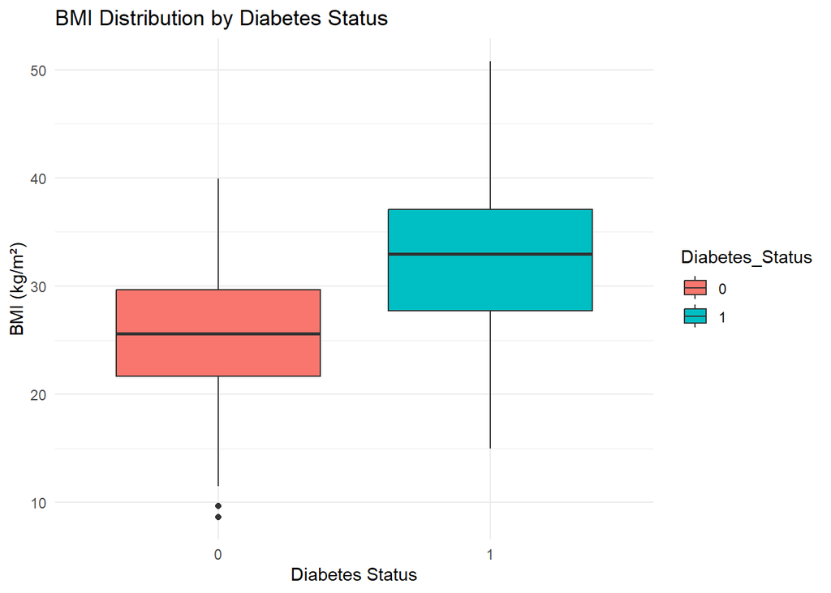

```r
# 4.3 Visualizations
# Box plot for BMI
ggplot(diabetes_df, aes(x = Diabetes_Status, y = BMI, fill = Diabetes_Status)) +
  geom_boxplot() +
  labs(title = "BMI Distribution by Diabetes Status", x = "Diabetes Status", y = "BMI (kg/m²)") +
  theme_minimal()
```

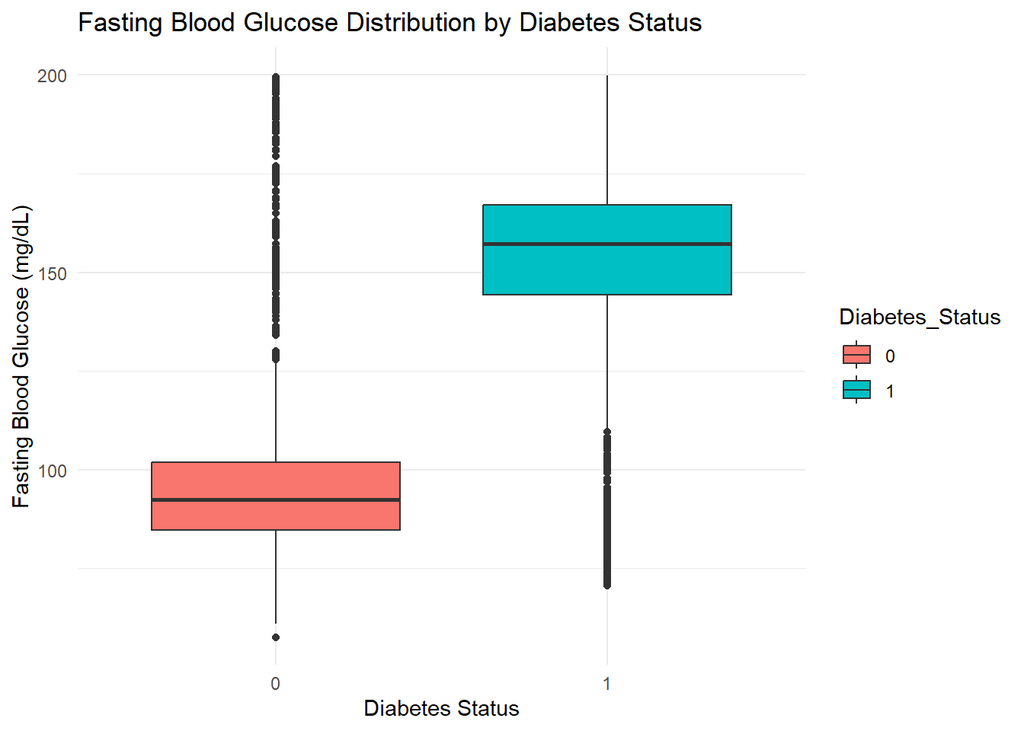

```r
# ggsave("boxplot_bmi.png") # Optional save

# Box plot for Glucose
ggplot(diabetes_df, aes(x = Diabetes_Status, y = Fasting_Blood_Glucose, fill = Diabetes_Status)) +
  geom_boxplot() +
  labs(title = "Fasting Blood Glucose Distribution by Diabetes Status", x = "Diabetes Status", y = "Fasting Blood Glucose (mg/dL)") +
  theme_minimal()
```

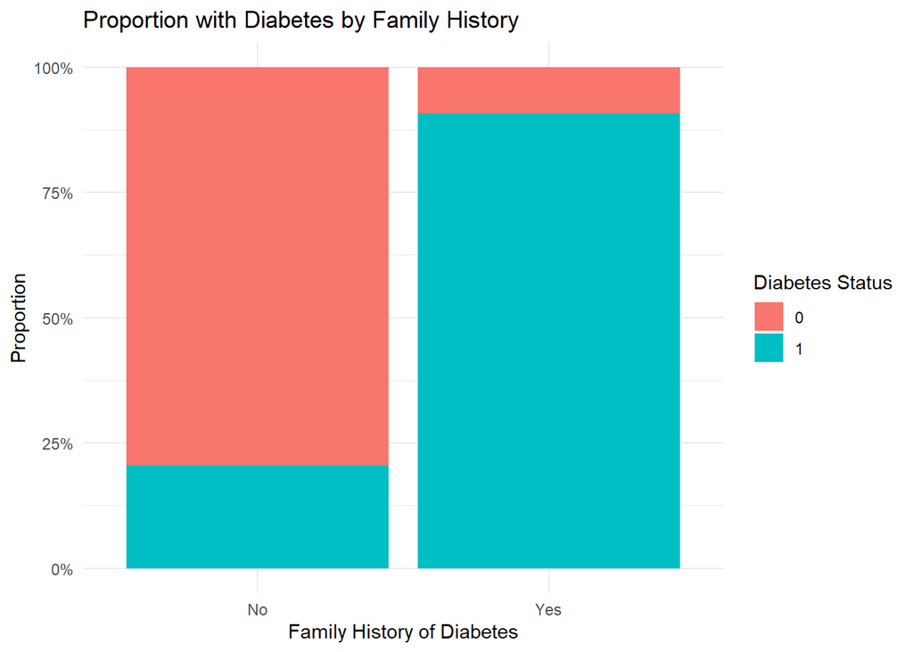

```r
# ggsave("boxplot_glucose.png") # Optional save


# Bar plot for Family History
ggplot(diabetes_df, aes(x = Family_History_of_Diabetes, fill = Diabetes_Status)) +
  geom_bar(position = "fill") + # Use position="fill" for proportions
  labs(title = "Proportion with Diabetes by Family History", x = "Family History of Diabetes", y = "Proportion", fill = "Diabetes Status") +
  scale_y_continuous(labels = scales::percent) +
  theme_minimal()
```

The box plot evaluation of BMI between patients who have diabetes and those without shows the direct relationship between body mass and diabetic status. A notable upward displacement of BMI values distinguished the entire distribution of ‘Positive’ diabetes from the ‘Negative’ diabetes group. The elevated status of median BMI and interquartile range in the box plot suggests diabetes patients within this sample had a tendency for higher body mass index on average.

A greater difference emerged from the fasting blood glucose box plot analysis. Research data via the plot showed that participants with ‘Positive’ diabetes status exhibited elevated fasting glucose concentrations. Visual inspection reveals how the ‘Positive’ group’s box and whiskers distribution stood at a higher position on the y-axis featuring extended whiskers which indicates more variable distribution compared to the ‘Negative’ group to display increased fasting glucose-diabetes connection strength.

The stacked bar plot presented in the figure effectively showed how family history affects diabetes. The proportion of people with positive diabetes status measurements who had family members with diabetes exceeded those who did not have family members with diabetes. This chart demonstrates that a greater proportion of individuals who had family members with diabetes received diagnostic results compared to those without family history of diabetes thus strengthening the evidence of an extensive correlation between family history and diabetes diagnosis in this research data.

# Conclusion

The research team evaluated information from 3,000 participants to establish important risk elements connected to diabetes through the combination of Logistic Regression and Random Forest modeling methods. Moving past data cleaning and descriptive and bivariate analysis the multivariate models produced important insights about factors that best distinguish diabetic from non-diabetic individuals.

These models demonstrated that metabolic elements and genetic predispositions should be acknowledged as main factors yet confirmed how lifestyle variables impact diabetes development. The findings indicate that scientists should focus on monitoring glucose levels and managing weight and understanding family risks for diabetes assessment while working to promote healthy habits among patients.